# Harry Potter Movie Review Analysis Weighted Title

## By Ali Ho

```python
#Packages and functions to be used
import os

#For regex
import re

#importing pandas
import pandas as pd

#To create a wordcloud/graphs
import numpy as np
from wordcloud import WordCloud, ImageColorGenerator
from PIL import Image
import matplotlib as mpl
import matplotlib.pyplot as plt
from matplotlib import cm
from colorspacious import cspace_converter
import seaborn as sns
#Allows for randomization, you can set a seed to have reproducable results
import random

#from PIL import Image
from PIL import ImageFilter
import numpy as np
#Allows for several values for the same dictionary key
import multidict

#To get a count of words (used in the term_frequency)
from collections import Counter

#NLTK Packages
#To process text using nltk (remove stopwords, lemmatize, tokenize...)
from nltk.corpus import stopwords
import nltk
from nltk.stem import WordNetLemmatizer
#Porter stemmer
from nltk.stem.porter import PorterStemmer

from nltk.sentiment.vader import SentimentIntensityAnalyzer as SIA

#To perform machine learning in Naive Bayes I need to import the following packages
from sklearn.model_selection import train_test_split
# To model the Gaussian Navie Bayes classifier
from sklearn.naive_bayes import GaussianNB
#Multinomrial classifier for naive bayes
from sklearn.naive_bayes import MultinomialNB
#SVMs
from sklearn.svm import SVC
# To calculate the accuracy score of the model
from sklearn.metrics import accuracy_score
#confusion matrix
from sklearn.metrics import confusion_matrix, classification_report
```

### Functions I created that will be used in the document:

```python
#Function 1: Creating a function to read in my files. This function will read in all the files in a specific directory.
    #inputs: list of all of the file names to read
    #        the path where the files are located
    #outputs: a list, each element in the list is the content for each file that was read in.
def reading_in_files(list_of_file_names, path):
    empty_list = []
    for file in list_of_file_names:
        file = open(path+ "\\" + file)
        data = file.read()
        empty_list.append(data)
        file.close()
    return(empty_list)

#Function 2: Creating a function to split the output from the just_compound_and_doc function.
    #inputs: the list that is to be split,
            #the item that we want to split on
    #outputs: a list of split lists that when put into a df, will create columns based on where the list was split
def list_split(list_to_be_split, item_to_split_on):
    empty_list = []
    for element in list_to_be_split:
        empty_list.append(element.split(item_to_split_on))
    return(empty_list)

#Function 2: Vader (from NLTK) sentiment intensity score calculator. This function will calculate the polarity score
#for each file. It will return a list of dictionaries. Each dictionary will contain the following: a compound score,
#positive score, negative score, neutral score, and the opinion.
    #inputs: a list of the content to be analyzed (this is what is returned in the reading_in_files function)
    #Output: a list of dictionaries. Each dictionary will contain the following: a compound score, postive score,
    #        negative score, neutral score, and the opinion
def sentiment_intensity_score(sentiment_files):
    sent_analyze = SIA()
    results = []
    for word in sentiment_files:
        score = sent_analyze.polarity_scores(word)
        score["sentiment_file"] = word
        results.append(score)
    return(results)


#Function 3:
    #What the function does: to be creating a list of reviews, then joining the reviews together to a string and
                             #getting a count for each word in the string
    #Input: df and column
    #Output: a dictionary with each word and the count of the word
def creating_freq_list_from_df_to_dict(df, column):
    reviews = df[column].tolist()
    review_string = " ".join(reviews)
    review_string = review_string.split()
    review_dict = Counter(review_string)
    return review_dict

#Function 3:
    #What the function does: creates a word cloud that is in the shape of the mask passed in
    #Input: the location where the mask image is saved, the frequency word dictionary, and the max # of words to include
            #and the title of the plot
def create_word_cloud_with_mask(path_of_mask_image, dictionary,
                                max_num_words, title):
        mask = np.array(Image.open(path_of_mask_image))
        #creating the word cloud
        word_cloud = WordCloud(background_color = "white",
                               max_words = max_num_words,
                              mask = mask, max_font_size = 125,
                              random_state = 1006)
        word_cloud.generate_from_frequencies(dictionary)
        #creating the coloring for the word cloud
        image_colors = ImageColorGenerator(mask)
        plt.figure(figsize = [8,8])
        plt.imshow(word_cloud.recolor(color_func = image_colors),
                  interpolation = "bilinear")
        plt.title(title)
        sns.set_context("poster")
        plt.axis("off")
        return plt

#Function 4:
    #What the function does: creates a df with two columns: word and count of the top 12 words
    #Input: the word frequency dictionary
    #Output: a df with the top 12 words
def word_freq_dict_to_df_top_words(dictionary, number_of_words_wanted):
    df = pd.DataFrame.from_dict(dictionary,orient='index')
    df.columns = ["count"]
    df["word"] = df.index
    df.reset_index(drop = True, inplace = True)
    df.sort_values(by=["count"], ascending = False, inplace = True)
    df = df[:number_of_words_wanted]
    return(df)

#Function 5:
    #What the function does: creates a bar graph
    #Input: the df and title of the graph
    #Output: the bar graph
def top_words_bar_plot(df, title):
    with sns.plotting_context("talk"):
        graph = sns.barplot(y = "count", x = "word", data = df,
                           palette = "GnBu_d")
        plt.title(title)
        plt.xlabel("Word")
        plt.ylabel("Count")
        plt.xticks(rotation = 90)
        return plt

#Function 6:
    #What the function does: creates a df with two columns: word and count
    #Input: the word frequency dictionary
    #Output: a df
def word_freq_dict_to_df_all_words(dictionary):
    df = pd.DataFrame.from_dict(dictionary,orient='index')
    df.columns = ["count"]
    df["word"] = df.index
    df.reset_index(drop = True, inplace = True)
    df.sort_values(by=["count"], ascending = False, inplace = True)
    return(df)

#Function 7:
    #What the function does: Returns 2 statements: One with the total number of words and the other with the number
                            #of unique words
        #Input: the frequency count dictionary
        #output: 2 statements
def total_words_unique_words(dictionary):
    eda_reviews_all_words = word_freq_dict_to_df_all_words(dictionary)
    print("The total number of words is", sum(eda_reviews_all_words["count"]))
    print("The total number of unique words is", len(dictionary))

#Function 8:
    #What the function does: It duplicates the words in each review that are in all caps.
    #Input: the review to be analyzed
    #Output: a new review where the first words of the review are the duplicated words from all caps and
            #then the original review follows
def duplicate_all_cap_words(review):
    capitalized_word = ""
    for word in re.findall('([A-Z][A-Z]+\w)', review):
        if word in review:
            capitalized_word = capitalized_word + " " + word
    new_review = capitalized_word +" " + review
    return new_review
#Function 9: Weighted Title
def duplicate_title(review):
    new_review = review + " " + review +" " + review + " " + review
    return(new_review)

#Function 8:
def get_count_of_all_cap_words(review):
    count = 0
    for word in re.findall('([A-Z][A-Z]+\w)', review):
        if word in review:
            count += 1
    return count

#Function 8:
def get_count_of_all_words(review):
    count = 0
    for word in re.findall('([A-z]+\w)', review):
        if word in review:
            count += 1
    return count

#Function 9:
    #What the function does: It removes all words that have less than 3 characters in it.
    #Input: The string to have stopwords removed
    #Ouptut: The string with the words with 2 or less characters removed
def remove_words_less_than_3_characters(string):
    new_string = ""
    for word in re.findall('[A-z][A-z]+\w', string):
        new_string = new_string + " " + word
    return new_string

#Function 10:
    #What the function does: Removes stopwords
    #Input: a list of stopwords to be removed, the tokenized item that you want to remove stopwords in
    #Output: the same item type back with the stopwords removed.
def stop_word_removal(stopwords, item_that_you_want_to_remove_stopwords_in):
    removed_stopwords = []
    for word in item_that_you_want_to_remove_stopwords_in:
        if word in stopwords:
            continue
        if word not in stopwords:
            removed_stopwords.append(word)
    return(removed_stopwords)

#Function11:
    #What the function does: It takes the tokens from the df and joins it into a string, then replaces the "," with a space
    #Input: the df and column to be changed
    #Output: the data untokenized
def getting_data_ready_for_freq(df, column):
    df[column] = df[column].apply(",".join)
    df[column] = df[column].str.replace(",", " ")
    return(df[column])

#Function 12:
    #What the function does: Takes the words in a column and uses the SentimentInstensityAnalyzer from nltk and
                             #gets the sentiment score for every word in the column. If the word has a sentiment
                             #score greater than or equal to .3 (max is 1) or less than or equal to -.3 (-1 is min)
                             #the word is added to the keep_words list if not the word will be removed.
def pos_neg_words(column):
    sia = SIA()
    keep_words = []

    for word in column:
        if (sia.polarity_scores(word)['compound']) >= 0.005:
            keep_words.append(word)
        elif (sia.polarity_scores(word)['compound']) <= -0.005:
            keep_words.append(word)
        elif word == "not":
            keep_words.append(word)
        else:
            continue
    return keep_words

#Function 13:
    #What the function does: It uses the Porter stemmer to stem each word in the column
    #Input: the item that you want to be stemmed
    #Output: the same item type back with the words stemmed
def stem_fun(item_that_you_want_to_be_stemmed):
    stemmer = PorterStemmer()
    stemmed = [stemmer.stem(token) for token in item_that_you_want_to_be_stemmed]
    return(stemmed)

#Function 14:
    #What the function does: It lemmatizes the data without using pos, meaning that it will not be as efficient
    #Input: item to be lemmatized (the column)
    #Output: the column lemmatized
def lemma_func(item_to_lemmatize):
    lemmatizer = WordNetLemmatizer()
    lemmatized_review = []
    for token in item_to_lemmatize:
        word = lemmatizer.lemmatize(token)
        lemmatized_review.append(word)
    return lemmatized_review

#Function 15:
    #What the function does: Creates bigrams from a tokenized column in a dataframe
    #Input: the column that you want to create a ngram with
    #Output: a list of ngrams
def creating_ngrams(item_to_be_ngrammed, number_of_ngram):
    # zip function helps generate ngrams
    ngrams = zip(*[item_to_be_ngrammed[i:] for i in range(number_of_ngram)])
    # Concatentate the tokens into ngrams and return
    return ["_".join(ngram) for ngram in ngrams]

#Function 16:
    #What the function does: Create a bag of words from a column in a df...
    #Input: df and column to be transformed
    #Output: A list of dictionaries for each row in the df that contains the word as a key and the count as the value
def bag_of_words(df, column_to_be_bagged):
    bag_of_words = []
    from collections import Counter
    for word in df[column_to_be_bagged]:
        bag_of_words.append(Counter(word))
    return bag_of_words

#Function 17:
    #What the function does: Takes the bag of words and makes it into a giant sparse matrix df, with 0s where nas are
    #Input: bag of words
    #Output: Giant df with the words as column names and counts as row entries
def bow_to_df(bag_of_words):
    df = pd.DataFrame.from_records(bag_of_words)
    df = df.fillna(0).astype(int)
    return(df)

#Function 18:
    #What the function does: It normalizing the df by getting the sum of each row and then dividing every entry by
                             #the sum, resulting in the percentage make-up of each word
    #Input: dataframe to be normalized
    #Output: normalized dataframe
def normalize_df(df):
    names = df.columns
    df["total"] = df.sum(axis = 1)
    for name in names:
        df[name] = df[name]/df["total"]
    return(df)

#Function 19:
    #What the function does: Creates a confusion matrix graph
    #Input: the confusion matrix, accuracy_label, and type of df
    #Output: Confusion matrix graph
def confusion_matrix_graph (cm, accuracy_label, type_of_df):
    g = plt.figure(figsize=(8, 8))
    g = sns.heatmap(cm, annot=True, fmt=".3f", linewidths=.5, square = True, cmap = 'Blues_r', cbar = False);
    g = plt.ylabel('Actual');
    g = plt.xlabel('Predicted');
    g = all_sample_title = type_of_df +' Accuracy Score: {0}'.format(round(accuracy_label, 4))
    g = plt.title(all_sample_title, size = 12);
    return(g)
```

```python
#First step is importing the documents
#Getting a list of all the file names in my pos file
positive = os.listdir("C:\\Users\\ho511\\Desktop\\IST_736\\homeworks\\week_3\\harry_potter_corpus\\pos")
positive_path = "C:\\Users\\ho511\\Desktop\\IST_736\\homeworks\\week_3\\harry_potter_corpus\\pos"

#Getting a list of all the file names in my neg file
negative = os.listdir("C:\\Users\\ho511\\Desktop\\IST_736\\homeworks\\week_3\\harry_potter_corpus\\neg")
negative_path = "C:\\Users\\ho511\\Desktop\\IST_736\\homeworks\\week_3\\harry_potter_corpus\\neg"
```

#### looking to see if I successfully got the file names

```python
print(positive[:10])
```

```
['10_hp1_0.txt', '10_hp1_1.txt', '10_hp1_10.txt', '10_hp1_11.txt', '10_hp1_12.txt', '10_hp1_13.txt', '10_hp1_14.txt', '10_hp1_15.txt', '10_hp1_16.txt', '10_hp1_18.txt']
```

#### looking at the first 10 items in the negative list to ensure I successfully extracted the file names

```python
print(negative[:10])
```

```
['1_hp1_1.txt', '1_hp1_10.txt', '1_hp1_11.txt', '1_hp1_12.txt', '1_hp1_13.txt', '1_hp1_14.txt', '1_hp1_15.txt', '1_hp1_16.txt', '1_hp1_17.txt', '1_hp1_18.txt']
```

#### Using my reading_in_file function to read in all of the positive files

```python
positive_reviews = reading_in_files(positive, positive_path)
```

```python
positive_reviews[3]
```

```
"10** Harry Potter and the Sorcerer's Stone\n== 10/10 - an unforgettable start to a fantastic film series and the career of the impeccable Emma Watson (and the other kids)"
```

#### The score is separated from the review by **, the title is separated from the review on ==. It is important to note, that if I split on the** , it is possible that the review will also be split. There is a high likelihood that the "**" characters are included in some of the review text as well. This will have to be addressed.

```python
positive_reviews = list_split(positive_reviews, "**")
```

#### Checking to make sure that it worked.

```python
positive_reviews[3]
```

```
['10',
 " Harry Potter and the Sorcerer's Stone\n== 10/10 - an unforgettable start to a fantastic film series and the career of the impeccable Emma Watson (and the other kids)"]
```

#### Changing the positive_review list to a data frame.

```python
positive_df = pd.DataFrame(positive_reviews)
```

```python
positive_df
```

|  | 0 | 1 | 2 | 3 | 4 | 5 | 6 | 7 | 8 | 9 | ... | 18 | 19 | 20 | 21 | 22 | 23 | 24 | 25 | 26 | 27 |
| --- | --- | --- | --- | --- | --- | --- | --- | --- | --- | --- | --- | --- | --- | --- | --- | --- | --- | --- | --- | --- | --- |
| 0 | 10 | The Magic Comes To Life!\n== Once upon a time... | None | None | None | None | None | None | None | None | ... | None | None | None | None | None | None | None | None | None | None |
| 1 | 10 | Pure Magic\n== This movie is a delight for th... | None | None | None | None | None | None | None | None | ... | None | None | None | None | None | None | None | None | None | None |
| 2 | 10 | Enchantment, Trapdoor to Imaginary World.\n==... | None | None | None | None | None | None | None | None | ... | None | None | None | None | None | None | None | None | None | None |
| 3 | 10 | Harry Potter and the Sorcerer's Stone\n== 10/... | None | None | None | None | None | None | None | None | ... | None | None | None | None | None | None | None | None | None | None |
| 4 | 10 | Great Journey to the Magic World\n== I watch ... | None | None | None | None | None | None | None | None | ... | None | None | None | None | None | None | None | None | None | None |
| ... | ... | ... | ... | ... | ... | ... | ... | ... | ... | ... | ... | ... | ... | ... | ... | ... | ... | ... | ... | ... | ... |
| 487 | 9 | I'm Sorry, Hermoine and Ron Who?\n== The one ... | None | None | None | None | None | None | None | None | ... | None | None | None | None | None | None | None | None | None | None |
| 488 | 9 | A fantastic ending\n== This movie was the per... | None | None | None | None | None | None | None | None | ... | None | None | None | None | None | None | None | None | None | None |
| 489 | 9 | LEGENDARY!\n== Best cinematic universe out th... | None | None | None | None | None | None | None | None | ... | None | None | None | None | None | None | None | None | None | None |
| 490 | 9 | Good but ending changed for worse\n== I was r... | None | None | None | None | None | None | None | None | ... | None | None | None | None | None | None | None | None | None | None |
| 491 | 9 | Great conclusion, of fantastic story\n== i wa... | None | None | None | None | None | None | None | None | ... | None | None | None | None | None | None | None | None | None | None |

492 rows × 28 columns

```python
positive_df["review"] = positive_df[positive_df.columns[1:]].apply(lambda row: " ".join(row.dropna().astype(str)), axis = 1)
```

```python
positive_title = positive_df["review"].tolist()
```

```python
positive_title[3]
```

```
" Harry Potter and the Sorcerer's Stone\n== 10/10 - an unforgettable start to a fantastic film series and the career of the impeccable Emma Watson (and the other kids)"
```

```python
positive_title = list_split(positive_title, "==")
```

```python
positive_df = pd.DataFrame(positive_title)
```

```python
positive_df.head()
```

|  | 0 | 1 |
| --- | --- | --- |
| 0 | The Magic Comes To Life!\n | Once upon a time (and not that long ago), in ... |
| 1 | Pure Magic\n | This movie is a delight for those of all ages... |
| 2 | Enchantment, Trapdoor to Imaginary World.\n | This is not a film, it is a trap door to a li... |
| 3 | Harry Potter and the Sorcerer's Stone\n | 10/10 - an unforgettable start to a fantastic... |
| 4 | Great Journey to the Magic World\n | I watch this movie again in 2019, because i t... |

```python
positive_df.columns = ["title", "review"]
```

#### This shows that my worry about the reviews being split on ** was warranted. I need to joing the review text to one column. Positive, is the the score was successfully extracted

```python
positive_df["title"] = positive_df["title"].apply(lambda row: duplicate_title(row))
```

```python
positive_df
```

|  | title | review |
| --- | --- | --- |
| 0 | The Magic Comes To Life!\n The Magic Comes T... | Once upon a time (and not that long ago), in ... |
| 1 | Pure Magic\n Pure Magic\n Pure Magic\n Pur... | This movie is a delight for those of all ages... |
| 2 | Enchantment, Trapdoor to Imaginary World.\n ... | This is not a film, it is a trap door to a li... |
| 3 | Harry Potter and the Sorcerer's Stone\n Harr... | 10/10 - an unforgettable start to a fantastic... |
| 4 | Great Journey to the Magic World\n Great Jou... | I watch this movie again in 2019, because i t... |
| ... | ... | ... |
| 487 | I'm Sorry, Hermoine and Ron Who?\n I'm Sorry... | The one that ends it all, after 8 films (7 bo... |
| 488 | A fantastic ending\n A fantastic ending\n A... | This movie was the perfect ending to the best... |
| 489 | LEGENDARY!\n LEGENDARY!\n LEGENDARY!\n LEG... | Best cinematic universe out there! Thank you ... |
| 490 | Good but ending changed for worse\n Good but... | I was really looking forward to this movie. T... |
| 491 | Great conclusion, of fantastic story\n Great... | i was looking forward to seeing the last part... |

492 rows × 2 columns

```python
positive_df["review"] = positive_df[positive_df.columns[:]].apply(lambda row: " ".join(row.dropna().astype(str)), axis = 1)
```

```python
positive_df.drop("title", axis = 1, inplace = True)
```

#### Changing the column names

```python
positive_df.head()
```

|  | review |
| --- | --- |
| 0 | The Magic Comes To Life!\n The Magic Comes T... |
| 1 | Pure Magic\n Pure Magic\n Pure Magic\n Pur... |
| 2 | Enchantment, Trapdoor to Imaginary World.\n ... |
| 3 | Harry Potter and the Sorcerer's Stone\n Harr... |
| 4 | Great Journey to the Magic World\n Great Jou... |

#### Repeating the process for the negative reviews

```python
negative_reviews = reading_in_files(negative, negative_path)
```

```python
negative_reviews[40]
```

[output not shown]

```python
negative_reviews = list_split(negative_reviews, "**")
```

```python
negative_reviews[0]
```

```
['1',
 ' For Kids Only, Unfortunately\n== ',
 '*SLIGHT SPOILERS',
 '* As an adult, it didn\'t appeal to me in the least. The effects were poorly done, the giant plot leap in the middle ("lots of strange things are happening-- hey, I know! it\'s definitely because the creepy teacher guy wants the thing under the trap door under the three-headed dog") threw me compl…
```

```python
negative_df = pd.DataFrame(negative_reviews)
negative_df.head()
```

|  | 0 | 1 | 2 | 3 | 4 | 5 | 6 | 7 | 8 | 9 | ... | 16 | 17 | 18 | 19 | 20 | 21 | 22 | 23 | 24 | 25 |
| --- | --- | --- | --- | --- | --- | --- | --- | --- | --- | --- | --- | --- | --- | --- | --- | --- | --- | --- | --- | --- | --- |
| 0 | 1 | For Kids Only, Unfortunately\n== | *SLIGHT SPOILERS | * As an adult, it didn't appeal to me in the l... | None | None | None | None | None | None | ... | None | None | None | None | None | None | None | None | None | None |
| 1 | 1 | An effects-laden excuse of an adaptation\n== ... | None | None | None | None | None | None | None | None | ... | None | None | None | None | None | None | None | None | None | None |
| 2 | 1 | Hollywood's greatest shame.\n== At first I li... | None | None | None | None | None | None | None | None | ... | None | None | None | None | None | None | None | None | None | None |
| 3 | 1 | Dismal, Contrived, Ripoff and just plain dumb... | None | None | None | None | None | None | None | None | ... | None | None | None | None | None | None | None | None | None | None |
| 4 | 1 | Great storytelling, no story\n== | SPOILERS | Before I briefly state my views, I must confes... |  |  | None | None | None | None | ... | None | None | None | None | None | None | None | None | None | None |

5 rows × 26 columns

```python
negative_df.shape
```

```
(492, 26)
```

```python
negative_df["review"] = negative_df[negative_df.columns[1:]].apply(lambda row: " ".join(row.dropna().astype(str)), axis = 1)
```

```python
negative_title = negative_df["review"].tolist()
negative_title = list_split(negative_title, "==")
negative_df = pd.DataFrame(negative_title)
```

```python
negative_df.head()
```

|  | 0 | 1 |
| --- | --- | --- |
| 0 | For Kids Only, Unfortunately\n | *SLIGHT SPOILERS * As an adult, it didn't ap... |
| 1 | An effects-laden excuse of an adaptation\n | Many viewers of this film applaud its faithfu... |
| 2 | Hollywood's greatest shame.\n | At first I liked the Harry Potter series, it ... |
| 3 | Dismal, Contrived, Ripoff and just plain dumb!\n | terribly contrived and juvenile. From the ou... |
| 4 | Great storytelling, no story\n | SPOILERS Before I briefly state my views, I ... |

```python
negative_df.columns = ["title", "review"]
```

```python
negative_df["title"] = negative_df["title"].apply(lambda row: duplicate_title(row))
```

```python
negative_df["review"] = negative_df[negative_df.columns[:]].apply(lambda row: " ".join(row.dropna().astype(str)), axis = 1)
negative_df.drop("title", axis = 1, inplace = True)
```

```python
negative_df
```

|  | review |
| --- | --- |
| 0 | For Kids Only, Unfortunately\n For Kids Only... |
| 1 | An effects-laden excuse of an adaptation\n A... |
| 2 | Hollywood's greatest shame.\n Hollywood's gr... |
| 3 | Dismal, Contrived, Ripoff and just plain dumb... |
| 4 | Great storytelling, no story\n Great storyte... |
| ... | ... |
| 487 | Deathly Disappointing\n Deathly Disappointin... |
| 488 | Nothing but disappointing.\n Nothing but dis... |
| 489 | A middling series ends on a low-point.\n A m... |
| 490 | OK but not I'm not Wowed!\n OK but not I'm n... |
| 491 | Its OK, not great.\n Its OK, not great.\n I... |

492 rows × 1 columns

## EDA for positive reviews and negative reviews

```python
positive_df.shape
```

```
(492, 1)
```

```python
negative_df.shape
```

```
(492, 1)
```

### Using my creating_freq_list_from_df_to_dict function

#### As part of the cleansing of the reviews, I am going to turn everything into lowercase, however, I do not want to lose the emphasis of words written in ALL CAPS. Therefore, I created a function, that will duplicate every word in the review that is in all caps. I think that it is fair, to count words in all caps as double.

```python
positive_df["new_review"] = positive_df.apply(lambda row: duplicate_all_cap_words(row["review"]), axis = 1)
```

```python
positive_df.head(10)
```

|  | review | new_review |
| --- | --- | --- |
| 0 | The Magic Comes To Life!\n The Magic Comes T... | The Magic Comes To Life!\n The Magic Comes ... |
| 1 | Pure Magic\n Pure Magic\n Pure Magic\n Pur... | Pure Magic\n Pure Magic\n Pure Magic\n Pu... |
| 2 | Enchantment, Trapdoor to Imaginary World.\n ... | IAN Enchantment, Trapdoor to Imaginary World... |
| 3 | Harry Potter and the Sorcerer's Stone\n Harr... | Harry Potter and the Sorcerer's Stone\n Har... |
| 4 | Great Journey to the Magic World\n Great Jou... | Great Journey to the Magic World\n Great Jo... |
| 5 | The beginning of a magical journey\n The beg... | The beginning of a magical journey\n The be... |
| 6 | Very Book Accurate and Enjoyable!!\n Very Bo... | VERY LOVES Very Book Accurate and Enjoyable!... |
| 7 | Great\n Great\n Great\n Great\n It brough... | Great\n Great\n Great\n Great\n It broug... |
| 8 | One of my favorites\n One of my favorites\n ... | JKR One of my favorites\n One of my favorit... |
| 9 | Absolutely amazing\n Absolutely amazing\n A... | Absolutely amazing\n Absolutely amazing\n ... |

```python
positive_df["cap_count"] = positive_df.apply(lambda row: get_count_of_all_cap_words(row["review"]), axis =1)
```

```python
positive_df.head(10)
```

|  | review | new_review | cap_count |
| --- | --- | --- | --- |
| 0 | The Magic Comes To Life!\n The Magic Comes T... | The Magic Comes To Life!\n The Magic Comes ... | 0 |
| 1 | Pure Magic\n Pure Magic\n Pure Magic\n Pur... | Pure Magic\n Pure Magic\n Pure Magic\n Pu... | 0 |
| 2 | Enchantment, Trapdoor to Imaginary World.\n ... | IAN Enchantment, Trapdoor to Imaginary World... | 1 |
| 3 | Harry Potter and the Sorcerer's Stone\n Harr... | Harry Potter and the Sorcerer's Stone\n Har... | 0 |
| 4 | Great Journey to the Magic World\n Great Jou... | Great Journey to the Magic World\n Great Jo... | 0 |
| 5 | The beginning of a magical journey\n The beg... | The beginning of a magical journey\n The be... | 0 |
| 6 | Very Book Accurate and Enjoyable!!\n Very Bo... | VERY LOVES Very Book Accurate and Enjoyable!... | 2 |
| 7 | Great\n Great\n Great\n Great\n It brough... | Great\n Great\n Great\n Great\n It broug... | 0 |
| 8 | One of my favorites\n One of my favorites\n ... | JKR One of my favorites\n One of my favorit... | 1 |
| 9 | Absolutely amazing\n Absolutely amazing\n A... | Absolutely amazing\n Absolutely amazing\n ... | 0 |

```python
positive_df["all_words_count"] = positive_df.apply(lambda row: get_count_of_all_words(row["review"]), axis = 1)
```

```python
positive_df.head(10)
```

|  | review | new_review | cap_count | all_words_count |
| --- | --- | --- | --- | --- |
| 0 | The Magic Comes To Life!\n The Magic Comes T... | The Magic Comes To Life!\n The Magic Comes ... | 0 | 969 |
| 1 | Pure Magic\n Pure Magic\n Pure Magic\n Pur... | Pure Magic\n Pure Magic\n Pure Magic\n Pu... | 0 | 104 |
| 2 | Enchantment, Trapdoor to Imaginary World.\n ... | IAN Enchantment, Trapdoor to Imaginary World... | 1 | 461 |
| 3 | Harry Potter and the Sorcerer's Stone\n Harr... | Harry Potter and the Sorcerer's Stone\n Har... | 0 | 43 |
| 4 | Great Journey to the Magic World\n Great Jou... | Great Journey to the Magic World\n Great Jo... | 0 | 94 |
| 5 | The beginning of a magical journey\n The beg... | The beginning of a magical journey\n The be... | 0 | 597 |
| 6 | Very Book Accurate and Enjoyable!!\n Very Bo... | VERY LOVES Very Book Accurate and Enjoyable!... | 2 | 112 |
| 7 | Great\n Great\n Great\n Great\n It brough... | Great\n Great\n Great\n Great\n It broug... | 0 | 17 |
| 8 | One of my favorites\n One of my favorites\n ... | JKR One of my favorites\n One of my favorit... | 1 | 79 |
| 9 | Absolutely amazing\n Absolutely amazing\n A... | Absolutely amazing\n Absolutely amazing\n ... | 0 | 19 |

```python
positive_df["percent_cap"] = positive_df["cap_count"]/positive_df["all_words_count"]
```

```python
positive_df.head(10)
```

|  | review | new_review | cap_count | all_words_count | percent_cap |
| --- | --- | --- | --- | --- | --- |
| 0 | The Magic Comes To Life!\n The Magic Comes T... | The Magic Comes To Life!\n The Magic Comes ... | 0 | 969 | 0.000000 |
| 1 | Pure Magic\n Pure Magic\n Pure Magic\n Pur... | Pure Magic\n Pure Magic\n Pure Magic\n Pu... | 0 | 104 | 0.000000 |
| 2 | Enchantment, Trapdoor to Imaginary World.\n ... | IAN Enchantment, Trapdoor to Imaginary World... | 1 | 461 | 0.002169 |
| 3 | Harry Potter and the Sorcerer's Stone\n Harr... | Harry Potter and the Sorcerer's Stone\n Har... | 0 | 43 | 0.000000 |
| 4 | Great Journey to the Magic World\n Great Jou... | Great Journey to the Magic World\n Great Jo... | 0 | 94 | 0.000000 |
| 5 | The beginning of a magical journey\n The beg... | The beginning of a magical journey\n The be... | 0 | 597 | 0.000000 |
| 6 | Very Book Accurate and Enjoyable!!\n Very Bo... | VERY LOVES Very Book Accurate and Enjoyable!... | 2 | 112 | 0.017857 |
| 7 | Great\n Great\n Great\n Great\n It brough... | Great\n Great\n Great\n Great\n It broug... | 0 | 17 | 0.000000 |
| 8 | One of my favorites\n One of my favorites\n ... | JKR One of my favorites\n One of my favorit... | 1 | 79 | 0.012658 |
| 9 | Absolutely amazing\n Absolutely amazing\n A... | Absolutely amazing\n Absolutely amazing\n ... | 0 | 19 | 0.000000 |

```python
positive_df.drop(["cap_count", "all_words_count"], axis = 1, inplace = True)
```

```python
positive_df.head()
```

|  | review | new_review | percent_cap |
| --- | --- | --- | --- |
| 0 | The Magic Comes To Life!\n The Magic Comes T... | The Magic Comes To Life!\n The Magic Comes ... | 0.000000 |
| 1 | Pure Magic\n Pure Magic\n Pure Magic\n Pur... | Pure Magic\n Pure Magic\n Pure Magic\n Pu... | 0.000000 |
| 2 | Enchantment, Trapdoor to Imaginary World.\n ... | IAN Enchantment, Trapdoor to Imaginary World... | 0.002169 |
| 3 | Harry Potter and the Sorcerer's Stone\n Harr... | Harry Potter and the Sorcerer's Stone\n Har... | 0.000000 |
| 4 | Great Journey to the Magic World\n Great Jou... | Great Journey to the Magic World\n Great Jo... | 0.000000 |

```python
positive_df.tail(10)
```

|  | review | new_review | percent_cap |
| --- | --- | --- | --- |
| 482 | Review - Harry Potter and the Deathly Hallows... | Review - Harry Potter and the Deathly Hallow... | 0.000000 |
| 483 | It's Official... Epic Movie, Epic Saga and Ep... | It's Official... Epic Movie, Epic Saga and E... | 0.000000 |
| 484 | sadly disappointing\n sadly disappointing\n ... | sadly disappointing\n sadly disappointing\n... | 0.000000 |
| 485 | The end is good..\n The end is good..\n The... | The end is good..\n The end is good..\n Th... | 0.000000 |
| 486 | They finally got it right!\n They finally go... | THIS HP7 THE They finally got it right!\n T... | 0.007092 |
| 487 | I'm Sorry, Hermoine and Ron Who?\n I'm Sorry... | I'm Sorry, Hermoine and Ron Who?\n I'm Sorr... | 0.000000 |
| 488 | A fantastic ending\n A fantastic ending\n A... | A fantastic ending\n A fantastic ending\n ... | 0.000000 |
| 489 | LEGENDARY!\n LEGENDARY!\n LEGENDARY!\n LEG... | LEGENDARY LEGENDARY LEGENDARY LEGENDARY LEGE... | 0.333333 |
| 490 | Good but ending changed for worse\n Good but... | Good but ending changed for worse\n Good bu... | 0.000000 |
| 491 | Great conclusion, of fantastic story\n Great... | AWESOME Great conclusion, of fantastic story... | 0.005618 |

#### repeating the process for the negative reviews df

```python
negative_df["new_review"] = negative_df.apply(lambda row: duplicate_all_cap_words(row["review"]), axis = 1)
```

```python
negative_df["cap_count"] = negative_df.apply(lambda row: get_count_of_all_cap_words(row["review"]), axis =1)
```

```python
negative_df["all_words_count"] = negative_df.apply(lambda row: get_count_of_all_words(row["review"]), axis = 1)
```

```python
negative_df.head(10)
```

|  | review | new_review | cap_count | all_words_count |
| --- | --- | --- | --- | --- |
| 0 | For Kids Only, Unfortunately\n For Kids Only... | SLIGHT SPOILERS For Kids Only, Unfortunately... | 2 | 197 |
| 1 | An effects-laden excuse of an adaptation\n A... | An effects-laden excuse of an adaptation\n ... | 0 | 191 |
| 2 | Hollywood's greatest shame.\n Hollywood's gr... | WOW HAD RINGWRAITHS ENTZ SHELOB YEAH Hollywo... | 6 | 598 |
| 3 | Dismal, Contrived, Ripoff and just plain dumb... | JRR Dismal, Contrived, Ripoff and just plain... | 1 | 189 |
| 4 | Great storytelling, no story\n Great storyte... | SPOILERS LOT Great storytelling, no story\n ... | 2 | 612 |
| 5 | It's bland like drinking warm water\n It's b... | It's bland like drinking warm water\n It's ... | 0 | 384 |
| 6 | Harry Potter and the Chamber of Commerce\n H... | Harry Potter and the Chamber of Commerce\n ... | 0 | 326 |
| 7 | its not worth the piece of paper the ticket w... | its not worth the piece of paper the ticket ... | 0 | 159 |
| 8 | My Revenge for the Non Fans!!\n My Revenge f... | AOL My Revenge for the Non Fans!!\n My Reve... | 1 | 367 |
| 9 | Terrible Terrible film\n Terrible Terrible f... | Terrible Terrible film\n Terrible Terrible ... | 0 | 330 |

```python
negative_df["percent_cap"] = negative_df["cap_count"]/negative_df["all_words_count"]
```

```python
negative_df.head(10)
```

|  | review | new_review | cap_count | all_words_count | percent_cap |
| --- | --- | --- | --- | --- | --- |
| 0 | For Kids Only, Unfortunately\n For Kids Only... | SLIGHT SPOILERS For Kids Only, Unfortunately... | 2 | 197 | 0.010152 |
| 1 | An effects-laden excuse of an adaptation\n A... | An effects-laden excuse of an adaptation\n ... | 0 | 191 | 0.000000 |
| 2 | Hollywood's greatest shame.\n Hollywood's gr... | WOW HAD RINGWRAITHS ENTZ SHELOB YEAH Hollywo... | 6 | 598 | 0.010033 |
| 3 | Dismal, Contrived, Ripoff and just plain dumb... | JRR Dismal, Contrived, Ripoff and just plain... | 1 | 189 | 0.005291 |
| 4 | Great storytelling, no story\n Great storyte... | SPOILERS LOT Great storytelling, no story\n ... | 2 | 612 | 0.003268 |
| 5 | It's bland like drinking warm water\n It's b... | It's bland like drinking warm water\n It's ... | 0 | 384 | 0.000000 |
| 6 | Harry Potter and the Chamber of Commerce\n H... | Harry Potter and the Chamber of Commerce\n ... | 0 | 326 | 0.000000 |
| 7 | its not worth the piece of paper the ticket w... | its not worth the piece of paper the ticket ... | 0 | 159 | 0.000000 |
| 8 | My Revenge for the Non Fans!!\n My Revenge f... | AOL My Revenge for the Non Fans!!\n My Reve... | 1 | 367 | 0.002725 |
| 9 | Terrible Terrible film\n Terrible Terrible f... | Terrible Terrible film\n Terrible Terrible ... | 0 | 330 | 0.000000 |

```python
negative_df.drop(["cap_count", "all_words_count"], axis = 1, inplace = True)
```

```python
negative_df.head(10)
```

|  | review | new_review | percent_cap |
| --- | --- | --- | --- |
| 0 | For Kids Only, Unfortunately\n For Kids Only... | SLIGHT SPOILERS For Kids Only, Unfortunately... | 0.010152 |
| 1 | An effects-laden excuse of an adaptation\n A... | An effects-laden excuse of an adaptation\n ... | 0.000000 |
| 2 | Hollywood's greatest shame.\n Hollywood's gr... | WOW HAD RINGWRAITHS ENTZ SHELOB YEAH Hollywo... | 0.010033 |
| 3 | Dismal, Contrived, Ripoff and just plain dumb... | JRR Dismal, Contrived, Ripoff and just plain... | 0.005291 |
| 4 | Great storytelling, no story\n Great storyte... | SPOILERS LOT Great storytelling, no story\n ... | 0.003268 |
| 5 | It's bland like drinking warm water\n It's b... | It's bland like drinking warm water\n It's ... | 0.000000 |
| 6 | Harry Potter and the Chamber of Commerce\n H... | Harry Potter and the Chamber of Commerce\n ... | 0.000000 |
| 7 | its not worth the piece of paper the ticket w... | its not worth the piece of paper the ticket ... | 0.000000 |
| 8 | My Revenge for the Non Fans!!\n My Revenge f... | AOL My Revenge for the Non Fans!!\n My Reve... | 0.002725 |
| 9 | Terrible Terrible film\n Terrible Terrible f... | Terrible Terrible film\n Terrible Terrible ... | 0.000000 |

#### Making everything lowercase

```python
positive_df["new_review"] = positive_df["new_review"].str.lower()
```

```python
positive_df.head(10)
```

|  | review | new_review | percent_cap |
| --- | --- | --- | --- |
| 0 | The Magic Comes To Life!\n The Magic Comes T... | the magic comes to life!\n the magic comes ... | 0.000000 |
| 1 | Pure Magic\n Pure Magic\n Pure Magic\n Pur... | pure magic\n pure magic\n pure magic\n pu... | 0.000000 |
| 2 | Enchantment, Trapdoor to Imaginary World.\n ... | ian enchantment, trapdoor to imaginary world... | 0.002169 |
| 3 | Harry Potter and the Sorcerer's Stone\n Harr... | harry potter and the sorcerer's stone\n har... | 0.000000 |
| 4 | Great Journey to the Magic World\n Great Jou... | great journey to the magic world\n great jo... | 0.000000 |
| 5 | The beginning of a magical journey\n The beg... | the beginning of a magical journey\n the be... | 0.000000 |
| 6 | Very Book Accurate and Enjoyable!!\n Very Bo... | very loves very book accurate and enjoyable!... | 0.017857 |
| 7 | Great\n Great\n Great\n Great\n It brough... | great\n great\n great\n great\n it broug... | 0.000000 |
| 8 | One of my favorites\n One of my favorites\n ... | jkr one of my favorites\n one of my favorit... | 0.012658 |
| 9 | Absolutely amazing\n Absolutely amazing\n A... | absolutely amazing\n absolutely amazing\n ... | 0.000000 |

```python
negative_df["new_review"] = negative_df["new_review"].str.lower()
```

```python
negative_df.head(10)
```

|  | review | new_review | percent_cap |
| --- | --- | --- | --- |
| 0 | For Kids Only, Unfortunately\n For Kids Only... | slight spoilers for kids only, unfortunately... | 0.010152 |
| 1 | An effects-laden excuse of an adaptation\n A... | an effects-laden excuse of an adaptation\n ... | 0.000000 |
| 2 | Hollywood's greatest shame.\n Hollywood's gr... | wow had ringwraiths entz shelob yeah hollywo... | 0.010033 |
| 3 | Dismal, Contrived, Ripoff and just plain dumb... | jrr dismal, contrived, ripoff and just plain... | 0.005291 |
| 4 | Great storytelling, no story\n Great storyte... | spoilers lot great storytelling, no story\n ... | 0.003268 |
| 5 | It's bland like drinking warm water\n It's b... | it's bland like drinking warm water\n it's ... | 0.000000 |
| 6 | Harry Potter and the Chamber of Commerce\n H... | harry potter and the chamber of commerce\n ... | 0.000000 |
| 7 | its not worth the piece of paper the ticket w... | its not worth the piece of paper the ticket ... | 0.000000 |
| 8 | My Revenge for the Non Fans!!\n My Revenge f... | aol my revenge for the non fans!!\n my reve... | 0.002725 |
| 9 | Terrible Terrible film\n Terrible Terrible f... | terrible terrible film\n terrible terrible ... | 0.000000 |

#### Now, I need to clean the reviews and remove any non-alpha characters, and the new line character, and space character. First, I want to change anything that ends in n't to the word and then not

```python
positive_df["new_review"] = positive_df["new_review"].str.replace(r"(n't)", "not")
```

```python
positive_df["new_review"] = positive_df["new_review"].str.replace(r"('m)", " am")
```

```python
# 'd can mean had or would... I am going to change it to would beause I feel that is most likely the the correct use for reviews
positive_df["new_review"] = positive_df["new_review"].str.replace(r"('d)", " would")
```

```python
positive_df["new_review"] = positive_df["new_review"].str.replace(r"('ll)", " will")
```

```python
#I am removing 's, I do not feel like it will be useful for the review as it shows plural or possessive
positive_df["new_review"] = positive_df["new_review"].str.replace(r"('s)", "")
```

```python
#I want to keep the word not
```

```python
positive_df.head()
```

|  | review | new_review | percent_cap |
| --- | --- | --- | --- |
| 0 | The Magic Comes To Life!\n The Magic Comes T... | the magic comes to life!\n the magic comes ... | 0.000000 |
| 1 | Pure Magic\n Pure Magic\n Pure Magic\n Pur... | pure magic\n pure magic\n pure magic\n pu... | 0.000000 |
| 2 | Enchantment, Trapdoor to Imaginary World.\n ... | ian enchantment, trapdoor to imaginary world... | 0.002169 |
| 3 | Harry Potter and the Sorcerer's Stone\n Harr... | harry potter and the sorcerer stone\n harry... | 0.000000 |
| 4 | Great Journey to the Magic World\n Great Jou... | great journey to the magic world\n great jo... | 0.000000 |

```python
negative_df["new_review"] = negative_df["new_review"].str.replace(r"(n't)", "not")
```

```python
negative_df["new_review"] = negative_df["new_review"].str.replace(r"('m)", " am")
```

```python
negative_df["new_review"] = negative_df["new_review"].str.replace(r"('d)", " would")
```

```python
negative_df["new_review"] = negative_df["new_review"].str.replace(r"('ll)", " will")
```

```python
negative_df["new_review"] = negative_df["new_review"].str.replace(r"('s)", "")
```

```python
negative_df.head(10)
```

|  | review | new_review | percent_cap |
| --- | --- | --- | --- |
| 0 | For Kids Only, Unfortunately\n For Kids Only... | slight spoilers for kids only, unfortunately... | 0.010152 |
| 1 | An effects-laden excuse of an adaptation\n A... | an effects-laden excuse of an adaptation\n ... | 0.000000 |
| 2 | Hollywood's greatest shame.\n Hollywood's gr... | wow had ringwraiths entz shelob yeah hollywo... | 0.010033 |
| 3 | Dismal, Contrived, Ripoff and just plain dumb... | jrr dismal, contrived, ripoff and just plain... | 0.005291 |
| 4 | Great storytelling, no story\n Great storyte... | spoilers lot great storytelling, no story\n ... | 0.003268 |
| 5 | It's bland like drinking warm water\n It's b... | it bland like drinking warm water\n it blan... | 0.000000 |
| 6 | Harry Potter and the Chamber of Commerce\n H... | harry potter and the chamber of commerce\n ... | 0.000000 |
| 7 | its not worth the piece of paper the ticket w... | its not worth the piece of paper the ticket ... | 0.000000 |
| 8 | My Revenge for the Non Fans!!\n My Revenge f... | aol my revenge for the non fans!!\n my reve... | 0.002725 |
| 9 | Terrible Terrible film\n Terrible Terrible f... | terrible terrible film\n terrible terrible ... | 0.000000 |

#### Time to remove any non-alpha characters

```python
positive_df["new_review"] = positive_df["new_review"].str.replace(r"[^\w^\s]", " ")
```

```python
positive_df["new_review"] = positive_df["new_review"].str.replace('\n'," ")
```

```python
positive_df
```

|  | review | new_review | percent_cap |
| --- | --- | --- | --- |
| 0 | The Magic Comes To Life!\n The Magic Comes T... | the magic comes to life the magic comes t... | 0.000000 |
| 1 | Pure Magic\n Pure Magic\n Pure Magic\n Pur... | pure magic pure magic pure magic pure ... | 0.000000 |
| 2 | Enchantment, Trapdoor to Imaginary World.\n ... | ian enchantment trapdoor to imaginary world... | 0.002169 |
| 3 | Harry Potter and the Sorcerer's Stone\n Harr... | harry potter and the sorcerer stone harry ... | 0.000000 |
| 4 | Great Journey to the Magic World\n Great Jou... | great journey to the magic world great jou... | 0.000000 |
| ... | ... | ... | ... |
| 487 | I'm Sorry, Hermoine and Ron Who?\n I'm Sorry... | i am sorry hermoine and ron who i am sor... | 0.000000 |
| 488 | A fantastic ending\n A fantastic ending\n A... | a fantastic ending a fantastic ending a ... | 0.000000 |
| 489 | LEGENDARY!\n LEGENDARY!\n LEGENDARY!\n LEG... | legendary legendary legendary legendary lege... | 0.333333 |
| 490 | Good but ending changed for worse\n Good but... | good but ending changed for worse good but... | 0.000000 |
| 491 | Great conclusion, of fantastic story\n Great... | awesome great conclusion of fantastic story... | 0.005618 |

492 rows × 3 columns

```python
negative_df["new_review"] = negative_df["new_review"].str.replace(r"[^\w^\s]", " ")
negative_df["new_review"] = negative_df["new_review"].str.replace('\n'," ")
```

```python
negative_df.head(10)
```

|  | review | new_review | percent_cap |
| --- | --- | --- | --- |
| 0 | For Kids Only, Unfortunately\n For Kids Only... | slight spoilers for kids only unfortunately... | 0.010152 |
| 1 | An effects-laden excuse of an adaptation\n A... | an effects laden excuse of an adaptation a... | 0.000000 |
| 2 | Hollywood's greatest shame.\n Hollywood's gr... | wow had ringwraiths entz shelob yeah hollywo... | 0.010033 |
| 3 | Dismal, Contrived, Ripoff and just plain dumb... | jrr dismal contrived ripoff and just plain... | 0.005291 |
| 4 | Great storytelling, no story\n Great storyte... | spoilers lot great storytelling no story ... | 0.003268 |
| 5 | It's bland like drinking warm water\n It's b... | it bland like drinking warm water it bland... | 0.000000 |
| 6 | Harry Potter and the Chamber of Commerce\n H... | harry potter and the chamber of commerce h... | 0.000000 |
| 7 | its not worth the piece of paper the ticket w... | its not worth the piece of paper the ticket ... | 0.000000 |
| 8 | My Revenge for the Non Fans!!\n My Revenge f... | aol my revenge for the non fans my reven... | 0.002725 |
| 9 | Terrible Terrible film\n Terrible Terrible f... | terrible terrible film terrible terrible f... | 0.000000 |

```python
#Removing any word that contains less than 3 characters
positive_df["new_review"] = positive_df.apply(lambda row: remove_words_less_than_3_characters(row["new_review"]), axis = 1)
```

```python
negative_df["new_review"] = negative_df.apply(lambda row: remove_words_less_than_3_characters(row["new_review"]), axis = 1)
```

```python
positive_df.head(10)
```

|  | review | new_review | percent_cap |
| --- | --- | --- | --- |
| 0 | The Magic Comes To Life!\n The Magic Comes T... | the magic comes life the magic comes life the... | 0.000000 |
| 1 | Pure Magic\n Pure Magic\n Pure Magic\n Pur... | pure magic pure magic pure magic pure magic t... | 0.000000 |
| 2 | Enchantment, Trapdoor to Imaginary World.\n ... | ian enchantment trapdoor imaginary world ench... | 0.002169 |
| 3 | Harry Potter and the Sorcerer's Stone\n Harr... | harry potter and the sorcerer stone harry pot... | 0.000000 |
| 4 | Great Journey to the Magic World\n Great Jou... | great journey the magic world great journey t... | 0.000000 |
| 5 | The beginning of a magical journey\n The beg... | the beginning magical journey the beginning m... | 0.000000 |
| 6 | Very Book Accurate and Enjoyable!!\n Very Bo... | very loves very book accurate and enjoyable v... | 0.017857 |
| 7 | Great\n Great\n Great\n Great\n It brough... | great great great great brought out almost ev... | 0.000000 |
| 8 | One of my favorites\n One of my favorites\n ... | jkr one favorites one favorites one favorites... | 0.012658 |
| 9 | Absolutely amazing\n Absolutely amazing\n A... | absolutely amazing absolutely amazing absolut... | 0.000000 |

```python
negative_df.head(10)
```

|  | review | new_review | percent_cap |
| --- | --- | --- | --- |
| 0 | For Kids Only, Unfortunately\n For Kids Only... | slight spoilers for kids only unfortunately f... | 0.010152 |
| 1 | An effects-laden excuse of an adaptation\n A... | effects laden excuse adaptation effects laden... | 0.000000 |
| 2 | Hollywood's greatest shame.\n Hollywood's gr... | wow had ringwraiths entz shelob yeah hollywoo... | 0.010033 |
| 3 | Dismal, Contrived, Ripoff and just plain dumb... | jrr dismal contrived ripoff and just plain du... | 0.005291 |
| 4 | Great storytelling, no story\n Great storyte... | spoilers lot great storytelling story great s... | 0.003268 |
| 5 | It's bland like drinking warm water\n It's b... | bland like drinking warm water bland like dri... | 0.000000 |
| 6 | Harry Potter and the Chamber of Commerce\n H... | harry potter and the chamber commerce harry p... | 0.000000 |
| 7 | its not worth the piece of paper the ticket w... | its not worth the piece paper the ticket was ... | 0.000000 |
| 8 | My Revenge for the Non Fans!!\n My Revenge f... | aol revenge for the non fans revenge for the ... | 0.002725 |
| 9 | Terrible Terrible film\n Terrible Terrible f... | terrible terrible film terrible terrible film... | 0.000000 |

#### Need to tokenize the reviews

```python
positive_df["review_tokenize"] = positive_df.apply(lambda row: nltk.word_tokenize(row["new_review"]), axis = 1)
```

```python
negative_df["review_tokenize"] = negative_df.apply(lambda row: nltk.word_tokenize(row["new_review"]), axis = 1)
```

```python
positive_df.head()
```

|  | review | new_review | percent_cap | review_tokenize |
| --- | --- | --- | --- | --- |
| 0 | The Magic Comes To Life!\n The Magic Comes T... | the magic comes life the magic comes life the... | 0.000000 | [the, magic, comes, life, the, magic, comes, l... |
| 1 | Pure Magic\n Pure Magic\n Pure Magic\n Pur... | pure magic pure magic pure magic pure magic t... | 0.000000 | [pure, magic, pure, magic, pure, magic, pure, ... |
| 2 | Enchantment, Trapdoor to Imaginary World.\n ... | ian enchantment trapdoor imaginary world ench... | 0.002169 | [ian, enchantment, trapdoor, imaginary, world,... |
| 3 | Harry Potter and the Sorcerer's Stone\n Harr... | harry potter and the sorcerer stone harry pot... | 0.000000 | [harry, potter, and, the, sorcerer, stone, har... |
| 4 | Great Journey to the Magic World\n Great Jou... | great journey the magic world great journey t... | 0.000000 | [great, journey, the, magic, world, great, jou... |

```python
negative_df.head()
```

|  | review | new_review | percent_cap | review_tokenize |
| --- | --- | --- | --- | --- |
| 0 | For Kids Only, Unfortunately\n For Kids Only... | slight spoilers for kids only unfortunately f... | 0.010152 | [slight, spoilers, for, kids, only, unfortunat... |
| 1 | An effects-laden excuse of an adaptation\n A... | effects laden excuse adaptation effects laden... | 0.000000 | [effects, laden, excuse, adaptation, effects, ... |
| 2 | Hollywood's greatest shame.\n Hollywood's gr... | wow had ringwraiths entz shelob yeah hollywoo... | 0.010033 | [wow, had, ringwraiths, entz, shelob, yeah, ho... |
| 3 | Dismal, Contrived, Ripoff and just plain dumb... | jrr dismal contrived ripoff and just plain du... | 0.005291 | [jrr, dismal, contrived, ripoff, and, just, pl... |
| 4 | Great storytelling, no story\n Great storyte... | spoilers lot great storytelling story great s... | 0.003268 | [spoilers, lot, great, storytelling, story, gr... |

```python
#Writing the pandas df to a csv file to save what I have done.
positive_df.to_csv(r'positive_hp_reviews.csv')
negative_df.to_csv(r'negative_hp_reviews.csv')
```

```python
#Now, I am going to remove a selected list of stopwords from the tokenized review
stopwords = ["the", "and", "was", "that", "this"]
```

```python
#Removing stopwords in the tokenized review
positive_df["stopwords_removed"] = positive_df["review_tokenize"].apply(lambda row: stop_word_removal(stopwords, row))
```

```python
positive_df.head()
```

|  | review | new_review | percent_cap | review_tokenize | stopwords_removed |
| --- | --- | --- | --- | --- | --- |
| 0 | The Magic Comes To Life!\n The Magic Comes T... | the magic comes life the magic comes life the... | 0.000000 | [the, magic, comes, life, the, magic, comes, l... | [magic, comes, life, magic, comes, life, magic... |
| 1 | Pure Magic\n Pure Magic\n Pure Magic\n Pur... | pure magic pure magic pure magic pure magic t... | 0.000000 | [pure, magic, pure, magic, pure, magic, pure, ... | [pure, magic, pure, magic, pure, magic, pure, ... |
| 2 | Enchantment, Trapdoor to Imaginary World.\n ... | ian enchantment trapdoor imaginary world ench... | 0.002169 | [ian, enchantment, trapdoor, imaginary, world,... | [ian, enchantment, trapdoor, imaginary, world,... |
| 3 | Harry Potter and the Sorcerer's Stone\n Harr... | harry potter and the sorcerer stone harry pot... | 0.000000 | [harry, potter, and, the, sorcerer, stone, har... | [harry, potter, sorcerer, stone, harry, potter... |
| 4 | Great Journey to the Magic World\n Great Jou... | great journey the magic world great journey t... | 0.000000 | [great, journey, the, magic, world, great, jou... | [great, journey, magic, world, great, journey,... |

```python
negative_df["stopwords_removed"] = negative_df["review_tokenize"].apply(lambda row: stop_word_removal(stopwords, row))
```

```python
negative_df.head()
```

|  | review | new_review | percent_cap | review_tokenize | stopwords_removed |
| --- | --- | --- | --- | --- | --- |
| 0 | For Kids Only, Unfortunately\n For Kids Only... | slight spoilers for kids only unfortunately f... | 0.010152 | [slight, spoilers, for, kids, only, unfortunat... | [slight, spoilers, for, kids, only, unfortunat... |
| 1 | An effects-laden excuse of an adaptation\n A... | effects laden excuse adaptation effects laden... | 0.000000 | [effects, laden, excuse, adaptation, effects, ... | [effects, laden, excuse, adaptation, effects, ... |
| 2 | Hollywood's greatest shame.\n Hollywood's gr... | wow had ringwraiths entz shelob yeah hollywoo... | 0.010033 | [wow, had, ringwraiths, entz, shelob, yeah, ho... | [wow, had, ringwraiths, entz, shelob, yeah, ho... |
| 3 | Dismal, Contrived, Ripoff and just plain dumb... | jrr dismal contrived ripoff and just plain du... | 0.005291 | [jrr, dismal, contrived, ripoff, and, just, pl... | [jrr, dismal, contrived, ripoff, just, plain, ... |
| 4 | Great storytelling, no story\n Great storyte... | spoilers lot great storytelling story great s... | 0.003268 | [spoilers, lot, great, storytelling, story, gr... | [spoilers, lot, great, storytelling, story, gr... |

```python
#Writing the pandas df to a csv file to save what I have done.
positive_df.to_csv(r'positive_hp_reviews.csv')
negative_df.to_csv(r'negative_hp_reviews.csv')
```

```python
#Now, I am going to visualize the stopwords_removed reviews and decide on what the next processing steps are.
#Visualizing the data without the stopwords
pos_viz = pd.DataFrame()
pos_viz["stopwords_removed"] = positive_df["stopwords_removed"].copy()
pos_viz["stopwords_removed"] = getting_data_ready_for_freq(pos_viz, "stopwords_removed")
stopwords_removed_dict_pos = creating_freq_list_from_df_to_dict(pos_viz, "stopwords_removed")
```

```python
neg_viz = pd.DataFrame()
neg_viz["stopwords_removed"] = negative_df["stopwords_removed"].copy()
neg_viz["stopwords_removed"] = getting_data_ready_for_freq(neg_viz, "stopwords_removed")
stopwords_removed_dict_neg = creating_freq_list_from_df_to_dict(neg_viz, "stopwords_removed")
```

```python
#Going to remove one more set of stopwords
stopwords = ["movie", "for", "they", "with", "have", "film", "all", "you", "are", "just", "there", "one", "what", "has",
            "his", "her", "your", "mine", "from", "not", "but", "like", "harry", "will", "good", "time", "will", "really", "story", "who"]
negative_df["stopwords_removed"] = negative_df["stopwords_removed"].apply(lambda row: stop_word_removal(stopwords, row))
positive_df["stopwords_removed"] = positive_df["stopwords_removed"].apply(lambda row: stop_word_removal(stopwords, row))
```

```python
positive_df.head()
```

|  | review | new_review | percent_cap | review_tokenize | stopwords_removed |
| --- | --- | --- | --- | --- | --- |
| 0 | The Magic Comes To Life!\n The Magic Comes T... | the magic comes life the magic comes life the... | 0.000000 | [the, magic, comes, life, the, magic, comes, l... | [magic, comes, life, magic, comes, life, magic... |
| 1 | Pure Magic\n Pure Magic\n Pure Magic\n Pur... | pure magic pure magic pure magic pure magic t... | 0.000000 | [pure, magic, pure, magic, pure, magic, pure, ... | [pure, magic, pure, magic, pure, magic, pure, ... |
| 2 | Enchantment, Trapdoor to Imaginary World.\n ... | ian enchantment trapdoor imaginary world ench... | 0.002169 | [ian, enchantment, trapdoor, imaginary, world,... | [ian, enchantment, trapdoor, imaginary, world,... |
| 3 | Harry Potter and the Sorcerer's Stone\n Harr... | harry potter and the sorcerer stone harry pot... | 0.000000 | [harry, potter, and, the, sorcerer, stone, har... | [potter, sorcerer, stone, potter, sorcerer, st... |
| 4 | Great Journey to the Magic World\n Great Jou... | great journey the magic world great journey t... | 0.000000 | [great, journey, the, magic, world, great, jou... | [great, journey, magic, world, great, journey,... |

```python
negative_df.head()
```

|  | review | new_review | percent_cap | review_tokenize | stopwords_removed |
| --- | --- | --- | --- | --- | --- |
| 0 | For Kids Only, Unfortunately\n For Kids Only... | slight spoilers for kids only unfortunately f... | 0.010152 | [slight, spoilers, for, kids, only, unfortunat... | [slight, spoilers, kids, only, unfortunately, ... |
| 1 | An effects-laden excuse of an adaptation\n A... | effects laden excuse adaptation effects laden... | 0.000000 | [effects, laden, excuse, adaptation, effects, ... | [effects, laden, excuse, adaptation, effects, ... |
| 2 | Hollywood's greatest shame.\n Hollywood's gr... | wow had ringwraiths entz shelob yeah hollywoo... | 0.010033 | [wow, had, ringwraiths, entz, shelob, yeah, ho... | [wow, had, ringwraiths, entz, shelob, yeah, ho... |
| 3 | Dismal, Contrived, Ripoff and just plain dumb... | jrr dismal contrived ripoff and just plain du... | 0.005291 | [jrr, dismal, contrived, ripoff, and, just, pl... | [jrr, dismal, contrived, ripoff, plain, dumb, ... |
| 4 | Great storytelling, no story\n Great storyte... | spoilers lot great storytelling story great s... | 0.003268 | [spoilers, lot, great, storytelling, story, gr... | [spoilers, lot, great, storytelling, great, st... |

```python
#Now, I am going to visualize the stopwords_removed reviews and decide on what the next processing steps are.
#Visualizing the data without the stopwords
pos_viz = pd.DataFrame()
pos_viz["stopwords_removed"] = positive_df["stopwords_removed"].copy()
pos_viz["stopwords_removed"] = getting_data_ready_for_freq(pos_viz, "stopwords_removed")
stopwords_removed_dict_pos = creating_freq_list_from_df_to_dict(pos_viz, "stopwords_removed")
```

```python
neg_viz = pd.DataFrame()
neg_viz["stopwords_removed"] = negative_df["stopwords_removed"].copy()
neg_viz["stopwords_removed"] = getting_data_ready_for_freq(neg_viz, "stopwords_removed")
stopwords_removed_dict_neg = creating_freq_list_from_df_to_dict(neg_viz, "stopwords_removed")
```

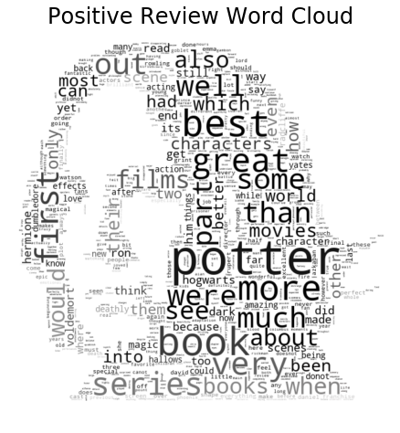

```python
#mask from: https://www.seekpng.com/ipng/u2r5w7e6r5q8e6t4_harry-potter-silhouette-clipart-harry-potter-and-the/
#creating an array of arrays for the mask
positive_word_cloud = create_word_cloud_with_mask("snape.PNG", stopwords_removed_dict_pos, 750, "Positive Review Word Cloud")
```

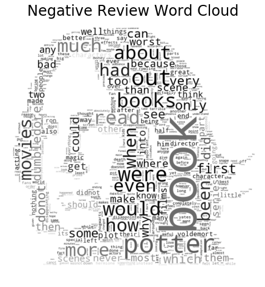

```python
#mask from https://www.seekpng.com/ipng/u2r5w7e6r5q8e6t4_harry-potter-silhouette-clipart-harry-potter-and-the/
#creating an array of arrays for the mask
negative_word_cloud = create_word_cloud_with_mask("snape.PNG", stopwords_removed_dict_neg, 750, "Negative Review Word Cloud")
```

```python
#Visualizing the top 12 words/characters
eda_reviews_top_words_pos = word_freq_dict_to_df_top_words(stopwords_removed_dict_pos, 20)
eda_reviews_top_words_pos
```

|  | count | word |
| --- | --- | --- |
| 44 | 1211 | potter |
| 147 | 760 | book |
| 210 | 659 | best |
| 144 | 599 | more |
| 156 | 531 | great |
| 175 | 495 | very |
| 413 | 488 | first |
| 511 | 471 | series |
| 94 | 437 | out |
| 97 | 417 | some |
| 143 | 394 | much |
| 77 | 387 | well |
| 145 | 385 | than |
| 119 | 380 | were |
| 218 | 364 | part |
| 774 | 357 | films |
| 499 | 351 | see |
| 206 | 343 | about |
| 89 | 341 | when |
| 236 | 340 | also |

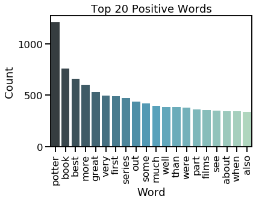

```python
positive_bar_plot = top_words_bar_plot(eda_reviews_top_words_pos, "Top 20 Positive Words")
```

```python
#Visualizing the top 12 words/characters
eda_reviews_top_words_neg = word_freq_dict_to_df_top_words(stopwords_removed_dict_neg, 20)
eda_reviews_top_words_neg
```

|  | count | word |
| --- | --- | --- |
| 108 | 1208 | book |
| 87 | 908 | potter |
| 38 | 645 | out |
| 10 | 555 | were |
| 97 | 514 | books |
| 41 | 499 | would |
| 45 | 486 | about |
| 200 | 480 | read |
| 53 | 460 | much |
| 80 | 444 | more |
| 164 | 441 | how |
| 79 | 431 | even |
| 204 | 419 | movies |
| 167 | 392 | when |
| 42 | 391 | been |
| 56 | 386 | had |
| 180 | 386 | first |
| 3 | 372 | only |
| 327 | 357 | see |
| 213 | 355 | did |

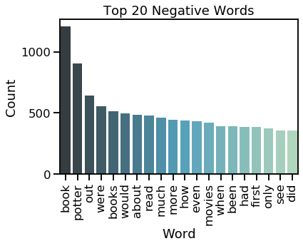

```python
negative_bar_plot = top_words_bar_plot(eda_reviews_top_words_neg, "Top 20 Negative Words")
```

```python
print("***** Positive *****")
total_words_unique_words(stopwords_removed_dict_pos)
print("***** Negative *****")
total_words_unique_words(stopwords_removed_dict_neg)
```

```
***** Positive *****
The total number of words is 88956
The total number of unique words is 9050
***** Negative *****
The total number of words is 89101
The total number of unique words is 9175
```

```python
#Adding a label to the positive reviews and negative reviews
positive_df["label"] = "pos"
negative_df["label"] = "neg"
```

```python
#Combining the positive and negative df together
combined_df = pd.concat([positive_df, negative_df])
```

```python
combined_df.head()
```

|  | review | new_review | percent_cap | review_tokenize | stopwords_removed | label |
| --- | --- | --- | --- | --- | --- | --- |
| 0 | The Magic Comes To Life!\n The Magic Comes T... | the magic comes life the magic comes life the... | 0.000000 | [the, magic, comes, life, the, magic, comes, l... | [magic, comes, life, magic, comes, life, magic... | pos |
| 1 | Pure Magic\n Pure Magic\n Pure Magic\n Pur... | pure magic pure magic pure magic pure magic t... | 0.000000 | [pure, magic, pure, magic, pure, magic, pure, ... | [pure, magic, pure, magic, pure, magic, pure, ... | pos |
| 2 | Enchantment, Trapdoor to Imaginary World.\n ... | ian enchantment trapdoor imaginary world ench... | 0.002169 | [ian, enchantment, trapdoor, imaginary, world,... | [ian, enchantment, trapdoor, imaginary, world,... | pos |
| 3 | Harry Potter and the Sorcerer's Stone\n Harr... | harry potter and the sorcerer stone harry pot... | 0.000000 | [harry, potter, and, the, sorcerer, stone, har... | [potter, sorcerer, stone, potter, sorcerer, st... | pos |
| 4 | Great Journey to the Magic World\n Great Jou... | great journey the magic world great journey t... | 0.000000 | [great, journey, the, magic, world, great, jou... | [great, journey, magic, world, great, journey,... | pos |

```python
combined_df
```

[output not shown]

984 rows × 7 columns

```python
#I need to reset the index
combined_df.reset_index(inplace = True)
```

```python
#Ready to see if I can predict the review sentiment
no_stopwords_df = pd.DataFrame()
no_stopwords_df["review"] = combined_df["stopwords_removed"].copy()
```

```python
no_stopwords_df["label"] = combined_df["label"]
```

```python
no_stopwords_df.head()
```

|  | review | label |
| --- | --- | --- |
| 0 | [magic, comes, life, magic, comes, life, magic... | pos |
| 1 | [pure, magic, pure, magic, pure, magic, pure, ... | pos |
| 2 | [ian, enchantment, trapdoor, imaginary, world,... | pos |
| 3 | [potter, sorcerer, stone, potter, sorcerer, st... | pos |
| 4 | [great, journey, magic, world, great, journey,... | pos |

```python
#Now I am going to create my bag of words for the tokenized reviews
#First, I must remove the labels that I just added...
no_stopwords_label = no_stopwords_df["label"]
no_stopwords_df.drop("label", axis = 1, inplace = True)
no_stopwords_bow = bag_of_words(no_stopwords_df, "review")
```

```python
no_stopwords_bow[3]
```

```
Counter({'potter': 4,
         'sorcerer': 4,
         'stone': 4,
         'unforgettable': 1,
         'start': 1,
         'fantastic': 1,
         'series': 1,
         'career': 1,
         'impeccable': 1,
         'emma': 1,
         'watson': 1,
         'other': 1,
         'kids': 1})
```

```python
no_stopwords_df = bow_to_df(no_stopwords_bow)
```

```python
no_stopwords_df.head()
```

|  | magic | comes | life | once | upon | long | ago | vivid | fertile | imagination | ... | peaks | payoffs | footnotes | wowed | lashed | sellout | wash | hairs | tingling | lump |
| --- | --- | --- | --- | --- | --- | --- | --- | --- | --- | --- | --- | --- | --- | --- | --- | --- | --- | --- | --- | --- | --- |
| 0 | 11 | 4 | 8 | 1 | 2 | 4 | 1 | 1 | 1 | 3 | ... | 0 | 0 | 0 | 0 | 0 | 0 | 0 | 0 | 0 | 0 |
| 1 | 5 | 0 | 0 | 0 | 0 | 0 | 0 | 0 | 0 | 0 | ... | 0 | 0 | 0 | 0 | 0 | 0 | 0 | 0 | 0 | 0 |
| 2 | 0 | 0 | 5 | 0 | 0 | 0 | 0 | 0 | 0 | 0 | ... | 0 | 0 | 0 | 0 | 0 | 0 | 0 | 0 | 0 | 0 |
| 3 | 0 | 0 | 0 | 0 | 0 | 0 | 0 | 0 | 0 | 0 | ... | 0 | 0 | 0 | 0 | 0 | 0 | 0 | 0 | 0 | 0 |
| 4 | 5 | 0 | 0 | 0 | 0 | 0 | 0 | 0 | 0 | 0 | ... | 0 | 0 | 0 | 0 | 0 | 0 | 0 | 0 | 0 | 0 |

5 rows × 12948 columns

```python
no_stopwords_df = normalize_df(no_stopwords_df)
```

```python
no_stopwords_df.head()
```

|  | magic | comes | life | once | upon | long | ago | vivid | fertile | imagination | ... | peaks | payoffs | footnotes | wowed | lashed | sellout | wash | hairs | tingling | lump |
| --- | --- | --- | --- | --- | --- | --- | --- | --- | --- | --- | --- | --- | --- | --- | --- | --- | --- | --- | --- | --- | --- |
| 0 | 0.020147 | 0.007326 | 0.014652 | 0.001832 | 0.003663 | 0.007326 | 0.001832 | 0.001832 | 0.001832 | 0.005495 | ... | 0.0 | 0.0 | 0.0 | 0.0 | 0.0 | 0.0 | 0.0 | 0.0 | 0.0 | 0.0 |
| 1 | 0.083333 | 0.000000 | 0.000000 | 0.000000 | 0.000000 | 0.000000 | 0.000000 | 0.000000 | 0.000000 | 0.000000 | ... | 0.0 | 0.0 | 0.0 | 0.0 | 0.0 | 0.0 | 0.0 | 0.0 | 0.0 | 0.0 |
| 2 | 0.000000 | 0.000000 | 0.018727 | 0.000000 | 0.000000 | 0.000000 | 0.000000 | 0.000000 | 0.000000 | 0.000000 | ... | 0.0 | 0.0 | 0.0 | 0.0 | 0.0 | 0.0 | 0.0 | 0.0 | 0.0 | 0.0 |
| 3 | 0.000000 | 0.000000 | 0.000000 | 0.000000 | 0.000000 | 0.000000 | 0.000000 | 0.000000 | 0.000000 | 0.000000 | ... | 0.0 | 0.0 | 0.0 | 0.0 | 0.0 | 0.0 | 0.0 | 0.0 | 0.0 | 0.0 |
| 4 | 0.092593 | 0.000000 | 0.000000 | 0.000000 | 0.000000 | 0.000000 | 0.000000 | 0.000000 | 0.000000 | 0.000000 | ... | 0.0 | 0.0 | 0.0 | 0.0 | 0.0 | 0.0 | 0.0 | 0.0 | 0.0 | 0.0 |

```python
#Now I need to remove the total column for each df
no_stopwords_df.drop("total", axis = 1, inplace = True)
```

```python
#Creating a testing and training df for the normalized dfs
no_stopwords_test_train = no_stopwords_df.copy()
test_train_label = combined_df["label"]
```

```python
#Creating 4 df: 1: the training df with label removed, 2: the testing df with label removed, 3: the training label, 4: testing label
no_stopwords_train, no_stopwords_test, no_stopwords_train_label, no_stopwords_test_label = train_test_split(no_stopwords_test_train, test_train_label, test_size = .3, random_state = 9)
```

```python
#Getting a count of positive and negative opinions in the test label
print(Counter(no_stopwords_test_label))
#There are roughly the same number of positive and negative reviews in the test and train set.
```

```
Counter({'pos': 148, 'neg': 148})
```

```python
#Naive Bayes attempt Multinomial
clf = MultinomialNB()
clf.fit(no_stopwords_train, no_stopwords_train_label)
test_predicted = clf.predict(no_stopwords_test)
#Getting the accuracy for naive bayes
accuracy = accuracy_score(no_stopwords_test_label, test_predicted, normalize = True)
print("The accuracy is", accuracy)
cm = confusion_matrix(no_stopwords_test_label, test_predicted)
# confusion_matrix_graph(cm, accuracy, "NB Multinomial No Stopwords")
tn, fp, fn, tp = cm.ravel()
print(cm)
print("The number of true negatives is: ", tn)
print("The number of false positives is: ", fp)
print("The number of false negatives is: ", fn)
print("The number of true positives is: ", tp)
```

```
The accuracy is 0.902027027027027
[[136  12]
 [ 17 131]]
The number of true negatives is:  136
The number of false positives is:  12
The number of false negatives is:  17
The number of true positives is:  131
```